# Coursera Johns Hopkins Data Science Reproduceable Research Peer Assignment

#### Overview

This is the first peer reviewed assignment for the Johns Hopkins Coursera Reproduceable Research class. The dataset is the measured steps of people, measured at 5 minute intervals throughout the day. The requirements are:

Code for reading in the dataset and/or processing the data

Histogram of the total number of steps taken each day

Mean and median number of steps taken each day

Time series plot of the average number of steps taken

The 5-minute interval that, on average, contains the maximum number of steps

Code to describe and show a strategy for imputing missing data

Histogram of the total number of steps taken each day after missing values are imputed

Panel plot comparing the average number of steps taken per 5-minute interval across weekdays and weekends

All of the R code needed to reproduce the results (numbers, plots, etc.) in the report

### Code for reading in the dataset and/or processing the data

First things first, read in the data, and take a gander.

```r
df <- read.csv("activity.csv")
head(df)
```

|  | steps | date | interval |
| --- | --- | --- | --- |
| 1 | NA | 2012-10-01 | 0 |
| 2 | NA | 2012-10-01 | 5 |
| 3 | NA | 2012-10-01 | 10 |
| 4 | NA | 2012-10-01 | 15 |
| 5 | NA | 2012-10-01 | 20 |
| 6 | NA | 2012-10-01 | 25 |

There’s a few ways to handle the NA’s but we’re going to wait to see how it unfolds

### Histogram of the total number of steps taken each day

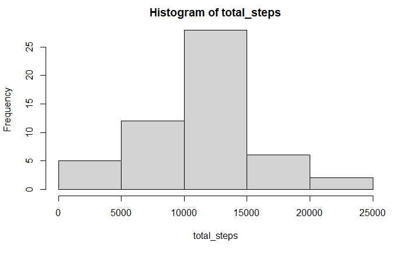

```r
total_steps <- tapply(df$step, df$date, FUN = sum)
hist(total_steps)
```

### Mean and median number of steps taken each day

Five number summary time

```r
summary(total_steps)
```

```
   Min. 1st Qu.  Median    Mean 3rd Qu.    Max.    NA's
     41    8841   10765   10766   13294   21194       8
```

### Time series plot of the average number of steps taken

It’s further documented in the assignment it’s the average number of steps taken at each interval, averaged across all days.

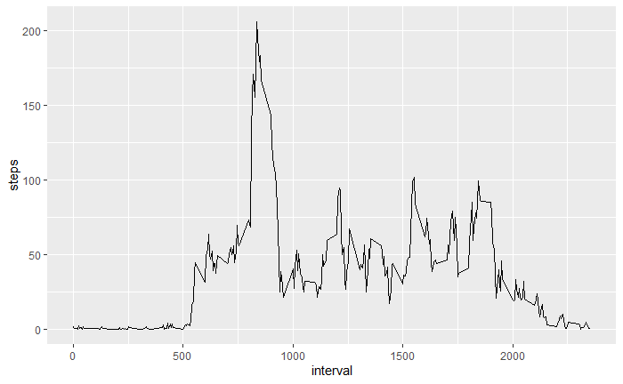

```r
ggplot(data = df, mapping = aes(x = interval, y = steps)) +
        stat_summary(fun = "mean", geom = "line")
```

### The 5-minute interval that, on average, contains the maximum number of steps

To accomplish this, we need to average intervals across all days, and report the max of that.

```r
which.max(tapply(df$steps, df$interval, FUN = mean, na.rm = TRUE))
```

```
835
104
```

Interval 835 has the max average number of steps. If we look at the graph above, that makes a lot of sense.

### Code to describe and show a strategy for imputing missing data

#### Calculate and report the total number of missing values in the dataset (i.e. the total number of rows with NA’S)

```r
nas <- is.na(df$steps)
sum(nas)
```

```
[1] 2304
```

2304 steps with NA rows.

#### Devise a strategy for filling in all of the missing values in the dataset. The strategy does not need to be sophisticated. For example, you could use the mean/median for that day, or the mean for that 5-minute interval, etc

#### Create a new dataset that is equal to the original dataset but with the missing data filled in.

This should be fun, and a good opportunity to use dplyr

```r
library(dplyr)

working_df <- df %>% group_by(interval) %>%
        mutate(steps = ifelse(is.na(steps), mean(steps, na.rm = TRUE), steps))

nas <- is.na(working_df$steps)
sum(nas)
```

```
[1] 0
```

So we have a dataset with no nas, so that’s good.

#### Histogram of the total number of steps taken each day after missing values are imputed

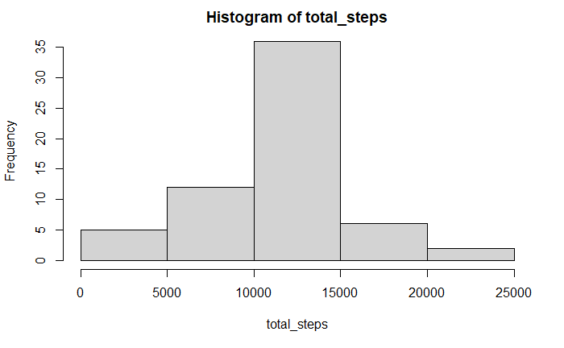

```r
total_steps <- tapply(working_df$steps, working_df$date, FUN = sum)
hist(total_steps)
```

```r
summary(total_steps)
```

```
   Min. 1st Qu.  Median    Mean 3rd Qu.    Max.
     41    9819   10766   10766   12811   21194
```

### Panel plot comparing the average number of steps taken per 5-minute interval across weekdays and weekends

```r
library(lubridate)

working_df$weekday_label <- ""
working_df$weekday <- wday(df$date, label = TRUE)
working_df$weekday_label[working_df$weekday == "Sun"] <- "Weekend"
working_df$weekday_label[working_df$weekday == "Sat"] <- "Weekend"
working_df$weekday_label[working_df$weekday_label != "Weekend"] <- "Weekday"
working_df$weekday_label <- as.factor(working_df$weekday_label)
```

Now we have a factor variable that differentiates weekdays from weekends. Now we can plot

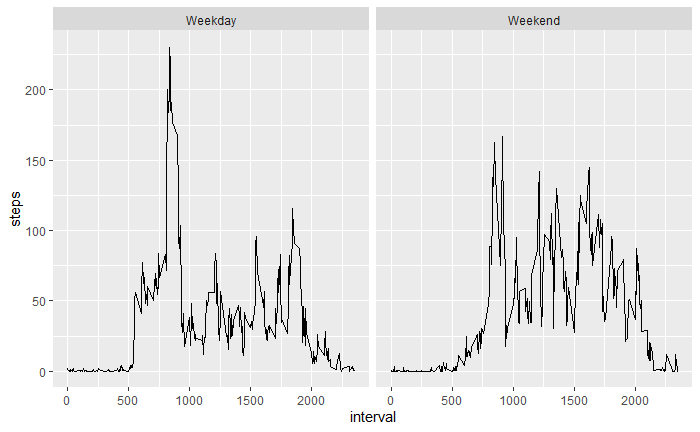